# Probability

4/20/2020

## Sample Space and events

- Probability formalizes chance variation or uncertainty in outcomes.
  - It might rain or be sunny today, we don’t know which.
  - To formalize, we need to define the set of possible outcomes.
- **Sample space:** \(\Omega\) the set of possible outcomes.
- **Event:** any subset of outcomes in the sample space

## What is probability?

\[\mbox{P(event)} = \dfrac{\mbox{number of outcomes in the event}}{\mbox{total number of outcomes in the sample space}}\]

- Consider tossing a fair coin:
  - There are two possible outcomes - tossing a head or tossing a tail.
  - The sample space is the set of all possible outcomes, so the sample space is {H, T}.
  - Since the coin is fair, the outcomes are equally likely. The probability of the event toss a head is 0.5. In symbols, we can write this as \(\mbox{P(H)}=0.5\)

## Events can be:

- **Independent** (each event is not affected by other events)
  - A coin does not “know” that it came up heads before … each toss of a coin is a perfect isolated thing.
- **Dependent** (also called “Conditional”, where an event is affected by other events)
  - After taking one card from the deck there are less cards available, so the probabilities change
- **Mutually Exclusive** (events can’t happen at the same time)
  - Heads and Tails are Mutually Exclusive
  - Kings and Hearts are not Mutually Exclusive, because we can have a King of Hearts!

## Notation

- \(P(A)\): Probability Of Event A
- \(P(A^c)\): The probability that Event A will not occur
- \(P(A\cap B\)): The probability that Events A and B both occur is the probability of the **intersection** of A and B.
- \(P(A\cup B\)): The probability that Events A or B occur is the probability of the **union** of A and B
- \(P(B \mid A)\): The **Conditional Probability** of B given A.

## Probability Axioms

- Probability quantifies how likely or unlikely events are.
- We’ll define the probability P(A) with three axioms:
1. (Nonnegativity) \(P(A) \ge 0\) for every event A
2. (Normalization) \(P(\Omega) = 1\)
3. (Addition Rule) If two events A and B are mutually exclusive \(P(A \text{or} B)\) = \(P(A) + P(AB)\)

## Complement of an Evenet

- Given an event \(A\), and its complement \(A^c\), the outcomes in \(\Omega\) which are not in \(A\), we have the complement rule:

\[P[A^c] = 1 - P[A]\]

-For instance, the probability of not throwing a 3 with a dice is:

\[P[A^c] = 1 - P[A] = 1-1/6 = 5/6\]

## Union of two event

- For two events A and B we have the **addition rule**:

\[P[A \cup B] = P[A] + P[B] - P[A \cap B]\]

## Union of two event

- Suppose that the probability of a fire breaking out in two houses in a given year is:
  - in house A: 60%, so \(P(A)=0.6\)
  - in house B: 45%, so \(P(B)=0.45\)
  - in at least one of the two houses: 80%, so \(P(A \cup B) =0.8\)
- By summing \(P(A)\) and \(P(B)\), the intersection of A and B, i.e. \(P(A \cap B )\), is counted twice. This is the reason we subtract it to count it only once.

## Disjoint Events

- If A and B are *disjoint*:

\[P[A \cup B] = P[A] + P[B]\]

## Intersection of two events

- If two events are independent, the probability of the intersection of the two events (i.e., the joint probability) is the probability of the two events occurring:

\[P(A \text{and} B) = P[A \cap B] = P[A] * P[B]\] - For instance, if two coins are flipped, the probability of both coins being tails is:

\[P[Tail_1 \cap Tail_2] = 1/2 * 1/2 = 1/4\]

## Conditional Probability

- Often, we would like to understand the probability of an event A, given some information about the outcome of event
- In that case, we have the **conditional probability rule**

\[P[A \mid B] = \frac{P[A \cap B]}{P[B]}\]

- Note that, in general, the probability of A given B is not equal to the probability of B given A, that is, \(P(A|B) \ne P(B|A)\)

## Multiplication Rule

- Rearranging the conditional probability rule, we obtain the multiplication rule:

\[P[A \cap B] = P[B] \cdot P[A \mid B]\]

## Bayes Theorem

From the formulas of the conditional probability and the multiplicative law, we can derive the Bayes’ theorem:

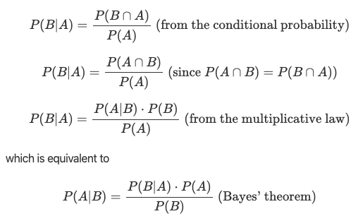

## Example - Healthcare

- In order to determine the presence of a disease in a person, a blood test is performed.
- When a person has the disease, the test can reveal the disease in 80% of cases. When the disease is not present, the test is negative in 90% of cases.
- Experience has shown that the probability of the disease being present is 10%.

## Example - Healthcare

- A researcher would like to know the probability that an individual has the disease given that the result of the test is positive.
- To answer this question, the following events are defined:
  - P: the test result is positive
  - D: the person has the disease

## Example - Healthcare

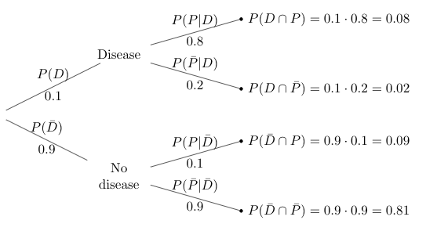

## Applying Bayes Rule

\[P[A \mid B] = \frac{P[A \cap B]}{P[B]}\]

\[P[Dis \mid Pos] = \frac{P[Dis \cap Pos]}{P[Pos]}\]

## Expected Values and Variance

- Most of the time we want to know what the expected value of a distribution is and its variance.
- The expected value of the binomial is the **mean** of the distribution.

\[E(X) = size * p\]

- The **variance** is defined as: The average of the squared differences from the Mean.
- To calculate the variance follow these steps: Work out the Mean (the simple average of the numbers) Then for each number: subtract the Mean and square the result (the squared difference).

\[Var(X) = size * p * (1-p)\]

## Frequentist vs. Bayesian

- **Frequentist**: probabilities reflect relative frequency in a large number of trials
- **Bayesian**: probabilities are subjective beliefs about outcomes
- Don’t worry about it … we’ll be sticking to frequentism in this class

## See also:

- https://tophat.com/marketplace/science-&-math/statistics/full-course/statistics-for-social-science-stephen-hayward/211/34407/
- https://towardsdatascience.com/the-9-concepts-and-formulas-in-probability-that-every-data-scientist-should-know-a0eb8d3ea8c4